# 시민의 교양 - 국가

Jae Kwan Koo

# 국가

## tutorial

실제로 개인의 삶은 거시적은 국가의 방향성과 직접적인 관계를 맺고 있다니 두렵지 않은가?  
개인의 삶을 규정하는 국가란 무엇인가?

### 국가와 나라?

같은 말로 보는 사람들이 대다수이고 실제로도 구분 없이 사용되지만, 차이점도 있다.

| type | description |
| --- | --- |
| 국가 | 법적, 정치적, 행정적인 측면이 강조되는 개념 |
| 나라 | 역사, 민족, 문화, 언어, 영토 등의 개념을 포괄하는 느슨하고 넓은 개념 |

| type | 책에서 말하는 어감상 느낌 |
| --- | --- |
| 국가 | 더 정돈되고 세련된 느낌 |
| 나라 | 막연하지만 친밀한 느낌 |

### 국가의 본질

| type | 개념 |
| --- | --- |
| 예전부터의 국가 | 고정된 무엇이라기보다는 시대와 사회의 요구에 따라 변화하는 유동적인 개념 |
| 오늘날 일반적으로 사용하는 국가 | 항구적인 영토와 국민을 기반으로 정치 조직으로서의 정부를 가지고 있는 정치적 실체 |

이것은 우리가 기대하는 답변으로 부족한 느낌이 든다. 국가에 대한 물음의 근저에는 **‘국가가 무엇을 해야 하는가?’**라는 당위적 역할에 대한 물음이 깔려 있다.

### 우리가 정말하고 싶은 질문

- 국가의 `역할`이란 무엇인가?
- 국가는 `무엇`이어야만 하는가?

## 야경국가와 복지국가

### 야경국가

1. (밤 야) 와 (경계할 경)으로 국가는 야간에 경비를 서는 정도의 역할만을 한다
2. 최소한의 역할을 수행하는 국가, 작고 효율적인 형태 지향
3. 국민의 생명과 재산을 보호하고 국방과 치안에 힘쓰지만, 국민 개개인의 삶의 방식이나 경제활동에는 간섭하지 않는 국가
4. 국민 전체가 행복해지는 길은 국민의 자유를 최대한 보장해주는 데서 시작된다고 본다.
   - 최대한의 자유를 보장하기 위해서는 국가가 시장에 개입하지 않아야 한다.
   - 세금을 낮추고 복지를 축소하는 방법을 취한다
   - 사회는 시장의 자유가 확보된다

원래는 노동자의 복지에는 신경 쓰지 않고 부유한 자본가의 재산만 지켜주는 당시의 국가를 비판하기 위해 19세기 독일에서 사회주의자 `라살레`가 사용했던 용어.

### 복지국가

1. 여기서 **복지**란 건강하고 윤택한, 궁극적인 행복의 상태를 의미
2. 역할이 많아짐에 따라 크고 거대한 형태를 띈다. 이에 따라 비효율의 문제를 발생시키기도 함
3. 국민 전체의 행복은 국가가 국민을 적극적으로 돌봐주는 데서 시작된다고 본다.
   - 국민의 복지를 향상시키기 위해서는 국가가 시장에 적극적으로 개입해야 한다.
   - 세금을 높이고 복지를 확대하는 방법을 취한다.
   - 사회는 정부의 개입이 강화된다.

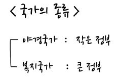

`자유주의` - 일반적으로 야경국가의 형태를 갖고 시장의 자유를 추구하는 이념  
`사회주의` - 일반적으로 복지국가의 형태를 갖고 정부의 개입을 추구하는 이념

오늘날 국가들을 단순하게 자유주의, 사회주의 혹은 야경국가, 복지국가로 단정하기는 쉽지 않다.

이 상반되는 개념들은 하나의 국가 안에서 갈등과 대립을 계속하고 있다.  
시장의 자유를 추구하려는 노력과 정부의 개입을 강화하려는 노력이 섞여 있다.  
이렇게 상반된 입장들은 해당 국가의 정치, 경제적 여건에 따라 조율되어 결국 하나의 방향성으로 드러난다.

**궁금한 건 누가 이러한 방향성을 최종적으로 결정하느냐 하는 것**

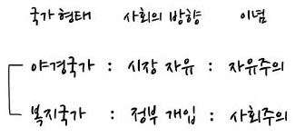

## 누가 국가의 방향을 결정하는가?

1. 가장 눈에 띄는 `왕`, `귀족/엘리트`를 각각의 집합으로 보자.
2. `나머지` - 백성, 국민, 인민, 민중, 대중 등 매우 다양하게 불리는데 사전적 정의와 함께 어감으로 구분해야 한다.

### 백성

**사전적 정의** – 국민을 예스럽게 이르는 말 (한자 뜻 : 100가지 성씨)

글자의 뜻만 보자면 오늘날의 사람들을 백성이라고 불러도 틀린 것은 아니지만 지칭하기에 적절한 어휘가 아니다.  
실제로 백성은 왕이 존재하는 사회의 피지배층을 지칭하는 어감이 강하다.

### 국민

**사전적 정의** - 국가를 구성하는 사람

오늘날 많이 사용하는 단어로 매우 익숙하고 자연스럽지만, 실제로 다수의 사람들을 지칭하기에 그렇게 자연스러운 단어는 아니다.

국가는 사라지거나 변화될 수 있는데 국가와 국민은 시대의 변화를 따르는 `가변적인 정치 개념`이다.

### 인민

**사전적 정의** - 국민에 비해 다수를 지칭하기에 더 자연스럽다(한자 뜻 : 사람)  
분단으로 인한 정치적 상황이 인민을 가장 정치적인 단어로 만들었다.  
북한에서 인민이라는 말을 사용하기 때문에 반감으로 이 단어를 사용하기 껄끄럽다.

### 민중

**사전적 정의** - 일반적인 사람들의 무리

사람들 전체를 지칭한다기보다는 소수의 지배자들을 제외한 다수의 피지배자들을 강조하는 방식으로 자주 사용된다.  
특히, 근대 노동자 계급을 지칭할 때 많이 사용되어왔다. 이 특성으로 민중이라는 단어 자체가 `사회의 부조리를 함축`하는 측면이 강하다.

### 대중

**사전적 정의** - 민중과 대비되는 단어

특색 없고 의식 없는, 그저 모여 있는 대다수의 무리를 말한다.  
민중처럼 다수의 무리를 지칭하지만, 어감상 부정적인 측면이 크다.

민중이 정치적이거나 계급대립적인 어감이 강한 데 비해서 대중은 수동적인 느낌이 강하다.

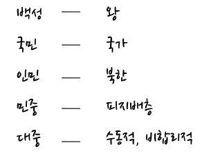

위의 단어들 중 어떤 것들은 이념적이고 어떤 것들은 수동적이다.  
하지만, 더 괜찮은 단어인 `시민`이 존재한다.

### **시민**

1. 권리를 갖고 있는 주체, 의무를 이행하고 권리를 갖는 주체 모두를 지칭
2. 협소한 의미 - 행정구역상 시에 거주하는 사람

왕과 귀족/엘리트를 제외한 대다수의 나머지들은 전체적으로 평등하다.  
하지만 부를 기준으로 하면 이 평등은 두 집단으로 분류된다.

1. `부르주아`
   - 근대에 들어서면서 산업화와 상업자본을 바탕으로 막대한 부를 소유한 사람들
   - 자본가, 유산계급 등으로 번역되기도 하는데 공장이나 농장, 거대 자본등의 생산수단을 소유한 사람들
2. `프롤레타리아`
   - 부를 소유하지 못한 사람들
   - 노동자, 무산계급으로 번역되는데, 먹고살기 위해 부르주아에게 자신의 노동력을 파는 사람들

## 중간정리

왕, 귀족/엘리트, 부르주아, 프롤레타리아 : 각 역사에서의 시대의 주인공이자 국가의 실질적 주인

## 네 가지 국가체제

국가의 근본 규범인 헌법이 왕과 어떤 관계를 맺느냐에 따라 전제군주제와 입헌군주제가 구분된다.

### 전제군주제 – 국가의 주인은 왕

1. 절대적인 통치권을 가진 군주가 법이나 백성들의 견제 없이 무제약적인 권력을 행사하는 정치체제
2. 의회는 존재하지 않음
3. 왕이 행정, 정치, 경제 등 국가의 모든 방향성을 결정
   - 헌법이 왕에게 종속되어 왕이 막강한 권한을 갖는다
4. 고대와 중세의 유럽, 아시아 국가들에서 쉽게 발견되는 정치 형태
   - 현재 : 사우디아라비아, 카타르, 브루나이

### 입헌 군주제 – 왕은 헌법에 종속된다

1. 왕의 권한이 법으로 제한된다
   - 왕이 헌법에 종속되어 그 안에서만 권한을 행사할 수 있다.

#### 헌법의 기원

오랜 역사 흐름 속에서 점진적을 형성되어온 까닭에 헌법의 기원을 말하기는 쉽지 않다.  
다만 13세기 초 영국에서 승인된 문서인 `<마그나카르타>`를 기원으로 보는 견해가 있다.

**마그나카르타**

13세기 영국의 왕 존은 계속해서 국내외 정책에 실패하고, 프랑스 침공을 위해 막대한 양의 세금을 귀족들로부터 징수하여 반발하게 된다.  
프랑스에게 또 패배하자 귀족들은 반란을 일으켰는데, 귀족들이 제안한 문서에 서명하게 된다. 이 문서가 마그나카르타이다

- 내용
  - 왕이 기본적인 세금 이외에 추가로 세금을 징수할 때는 귀족들로 구성된 회의의 동의를 얻을 것
  - 왕의 권한으로 부터 자유로운 도시들에 대해서는 관세를 면제할 것
  - 왕으로부터 교회의 권한을 분리할 것

#### 의회의 기원

존의 사망이후 아들 헨리3세는 마그나카르타를 인정하지 않았다. 이에 반발하여 대귀족과 고위성직자뿐 아니라 각 자치시의 대표자들까지 참여한 회의가 열렸고, 이 회의를 `의회`라고 불렀다.

왕과 의외의 권한이 확대 축소를 반복하였는데 1688년 귀족과 시민들의 이익과 권리를 보장하기 위한 `명예 혁명`이 일어나게 된다.  
다음 해 12월, 시민의 권리와 자유를 선언하고 왕의 권한을 규정하는 법률로서 `권리장전`이 승인된다.

**명예혁명과 권리장전은 전제군주제가 폐지되고 입헌군주제가 확립되는 결정적 계기가 되었다.**

### 공화제 – 왕이 아닌 사람이 국가의 주인이다.

| type | description |
| --- | --- |
| 군주제 | 왕이 존재하는 국가체제 |
| 공화제 | 왕이 존재하지 않는 국가체제 |

`공화` : republic, 공공의 것을 뜻하는 res publica에서 왔다.  
-> 국가가 특정인의 소유가 아니라 모두의 것이라는 의미

#### 공화 어원의 기원

기원전 9세기 중엽, 중국 주나라에 폭군 여왕이 있었다. ‘여왕’은 여자 왕이 아니라 이름이다. ‘여(厲)’왕. 그는 이익을 독점하기 위해서 토지와 산림을 장악하고 백성들은 사용하지 못하게 했다. 백성들이 불만을 표출하자 공포정치를 시작했다. 불만을 가진 사람들을 모조리 죽인 것이다. 이에 백성들이 더 이상 참지 못하고 폭동을 일으켰다. 그러자 여왕은 나라를 버리고 도망쳤다. 이때부터 왕이 없는 14년의 시기가 이어졌는데, 이때가 공화시대로 불린다.

왜 14년 동안의 기간을 공화시대라고 하는가?

1. 우선 왕이 자리를 비운 사이 주공과 소공이라는 두 제후가 함께 정치를 관장했기 때문에 ‘공화’라는 설이 있다.
2. ‘공’나라 땅의 제후였던 ‘화’라는 사람이 왕의 업무를 대행했기 때문에 ‘공화’라는 설도 있다.

어쨌거나 후에 ‘리퍼블릭’을 번역해야 했던 일본의 번역가들이 적절한 낱말을 찾던 중에, 왕이 없던 중국의 이 시기에서 단어를 차용한 것이 ‘공화’의 기원으로 여겨진다.

#### 공화제의 다양한 형태의 국가체제

[output not shown]

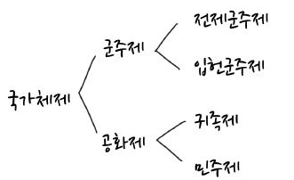

### 민주제 – 국가의 주인은 국민 전체다

공화제와 민주제는 공통적으로 왕이 없는 정치체제로, 개념상 민주제가 공화제에 포함되는 관계다

1. 공화제
- 집권자가 국민 전체일뿐만 아니라, 두 명이거나 소수 집단인 경우도 포함
- 소수 귀족이나 에리트에 의한 통치를 긍정
2. 민주제
- 계급이나 계층의 구분 없이 모든 국민에 의한 정치만을 의미

**즉, 이것은 엘리트주의와 민주주의 의 대립으로 볼 수 있다.**

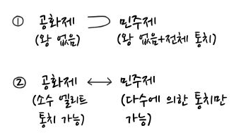

#### 민주주의를 보는 시선?

오늘날 우리는 민주주의를 최선의 정치체제로 알고 있고, 그 가치를 지켜나가는 것을 자연스럽게 생각한다.

1. 고대

|  | description |
| --- | --- |
| `플라톤` | 민주제를 어리석은 다수에 의한 정치라는 의미의 `중우정치` |
| `아리스토텔레스` | 다수의 가난한 자들에 의한 정치라는 의미에서 민주주의를 `빈민정치`라고 규정 |

2. 현대
- 많은 정치가와 사상가가 민주주의의 근본인 다수결의 원리가 얼마나 비합리적 결론을 도출하는지를 우려한다.
- 대중은 현명한 판단을 내리기 귀찮아 하기 때문에 선동가와 군중심리에 쉽게 휩쓸리고, 자신과 집단의 이익에 반하는 선택을 한다.
- 소수의 의견이 존중되고 표현의 자유가 확보된 상황에서 충분한 대화와 토론이 전제되어야 하는데, 대중에게 이를 기대하기는 현실적으로 어렵다는 것
- 강력한 전제정부가 경제를 성장시키고 삶의 질을 개선한다는 주장
  - 1960~80년대까지 동아시아의 눈부신 경제성장이 그 근거가 된다.  
    한국의 군부독재를 비롯대 대만의 장제스, 싱가포르의 리콴유 등과 같은 전제정부는 독재를 통해 효율적인 의사결정과 강력한 추진력으로 경제성장을 이룩했다는 것

##### 사실의 측면

비판의견 : 빠르게 성장한 몇몇 개발도상국의 사례를 확인했더니 하필이면 그 사회의 정치체제가 독재였다고 해서, 역으로 독재가 경제를 성장시킨다고 생각할 수는 없다는 말이다.

반대 사례 : 한국, 대만, 싱가포르가 강력한 전제정부 아래 성장하던 같은 시기에 똑같이 전제정부를 유지했던 중국과 북한, 필리판, 미얀마는 당시에 경제적으로 긍정적인 성과를 보여주지 못했다. 동아시아의 눈부신 발전 사례는 독재가 민주주의보다 우월하다고 판단하는 근거가 되지 않는다. 인적 역량, 교육, 외교관계 등의 다른 요인이 경제적 성장과 실패를 낳은 것이다.

##### 당위의 측면

우리가 민주주의를 추구하는 것은 물질적인 성장 때문이 아니라 이념적인 측면에서 마땅히 그러해야 하기 때문이라는 것

내 이익과 결부된 문제에서 정치적 의사결정의 권한이 없는 자는 주인이라고 할 수 없다. 경제가 성장하든 실패하든, 그에 대한 책임과 후회는 주인으로서의 시민 스스로가 져야 한다. 경제성장을 빌미로 나의 정치적 의사결정 권한을 제한하는 행위는 주인으로서 강력히 저항하고 맞서 싸워야 한다는 것

#### 엘리트주의와 민주주의

|  | description |
| --- | --- |
| 엘리트주의 | 소수에 의한 정치 |
| 민주주의 | 전체에 의한 정치 |

중요한 것은 오늘날에 이르러 표면적인 측면에서는 민주주의가 승리했다는 것

**시장을 성장시키는 주체가 누구인가에 대한 문제**

1. 시장을 성장시키고 사회적 부를 증진시키는 소수의 엘리트가 경제의 주인공, 이들이 사회를 견인할 수 있도록 환경을 조성해야 한다.
2. 시장을 구성하는 민중 전체가 경제의 주인공, 전체의 이익이 우선 보장되어야 한다.

현대적 의미의 엘리트 : 자본가(국가와 사회의 이익을 창출하고 시장의 혁신을 주도하는 주체)

B : 시장에서 가장 시급한 문제는 양극화, 민중의 삶의 질을 개선하는 것이 국가의 근본 목적

기업과 재벌의 세금을 높이고 규제를 강화함으로써 적극적인 복지 정책을 시행해야 바른 길로 간다

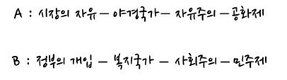